# GEOG 3023: Statistics for Geography

Lab 8: Linear Regression

Gavin Unrue

*Please complete the following questions and submit the finished Rmd and HTML files onto Canvas.*

Don’t forget to change name field in the beginning to your **first and last name**.

### Data: Crime and Inequality

In this lab, we’ll continue investigating factors associated with violent crime rates. *Note that this is a similar but NOT identical dataset to the one you used in Lab 7!*

The data come from *Statistical Methods for the Social Sciences* (Agresti & Finlay, 1997), and include the variables:

- **crime**: Violent crimes per 100,000 people
- **murder**: Murders per 1,000,000 people
- **pctmetro**: Percent of the population living in metropolitan areas
- **pctwhite**: Percent of the population that is white
- **pcths**: Percent of the population with a high school education or above
- **poverty**: Percent of the population living under the poverty line
- **single**: Percent of the population that are single parents

Our goal is to use **simple** and **multiple** linear regression to understand which factors best predict violent crime rates, and to practice interpreting regression output and diagnostics.

### Getting Started

#### Load packages

We will use the `dplyr` package for data wrangling and base R functions for modeling and plotting.

```r
library(dplyr)

lab8<- read.csv("Lab8_data.csv")

## Add region:
lab8<- lab8 %>%
  mutate(region = case_when(
    State %in% c("ME", "NH", "VT", "MA", "RI", "CT", "NY", "NJ", "PA") ~ "NE",  # Northeast
    State %in% c("OH", "MI", "IN", "IL", "WI", "MN", "IA", "MO") ~ "MW",        # Midwest
    State %in% c("DE", "MD", "VA", "NC", "SC", "GA", "FL", "AL", "MS") ~ "SE",  # Southeast
    State %in% c("TN", "KY", "AR", "LA", "OK", "TX") ~ "S",                     # South / South-Central
    State %in% c("ND", "SD", "MT", "WY", "ID", "WA", "OR") ~ "NW",              # Northwest
    State %in% c("CA", "NV", "UT", "CO", "AZ", "NM") ~ "SW",                    # Southwest
    State %in% c("AK", "HI") ~ "W",                                             # West (outliers)
    TRUE ~ NA_character_                                                         # For any unmatched state
  ))
```

### Exploring Relationships

Before fitting any models, let’s take a look at the data. In Lab 7, you already looked at the variables poverty, pcths, and single.

**Q1:** Plot the relationship between crime (response variable) and pctmetro (explanatory variable). *Note: these are both continuous variables.* [2 points]

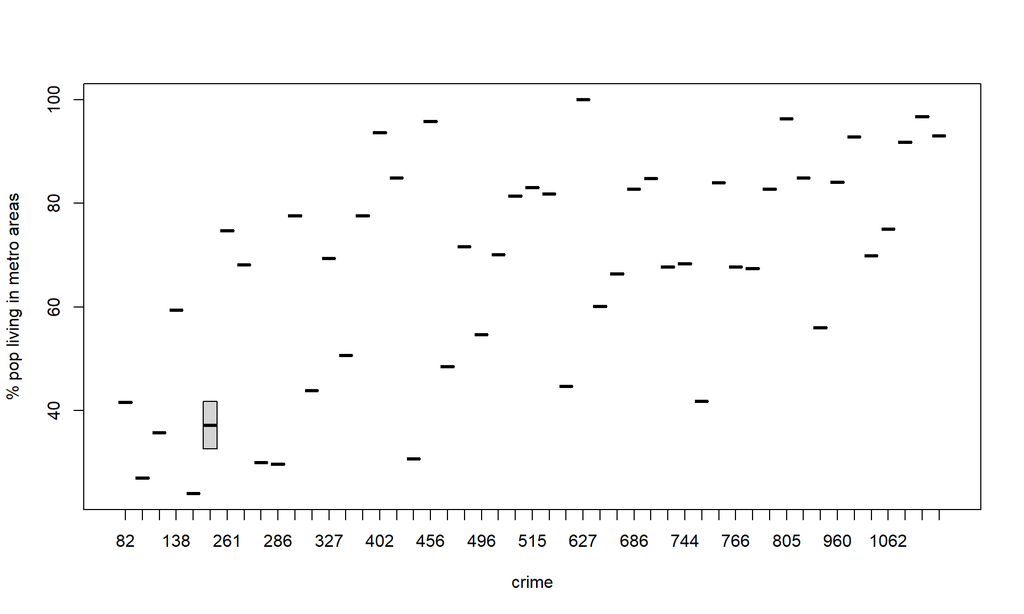

```r
# type your code here


# Plot to compare groups visually
par(mfrow=c(1,1))
boxplot(pctmetro ~ crime, data = lab8,
        xlab = "crime",
        ylab = "% pop living in metro areas")
```

**Q2:** Does there appear to be a linear correlation between these variables, and if so is it positive or negative? [3 points]

**Your answer:**

It appears that there is a positive linear correlation between these variables.

### Now let’s fit a simple linear regression

We can fit a simple linear regression model using the lm() function.

```r
m1<- lm(crime ~ pctmetro, data = lab8)
summary(m1)
```

```
##
## Call:
## lm(formula = crime ~ pctmetro, data = lab8)
##
## Residuals:
##     Min      1Q  Median      3Q     Max
## -382.45 -182.81    1.09  163.98  450.40
##
## Coefficients:
##             Estimate Std. Error t value Pr(>|t|)
## (Intercept)   25.558    111.117   0.230    0.819
## pctmetro       8.108      1.585   5.115 5.44e-06 ***
## ---
## Signif. codes:  0 '***' 0.001 '**' 0.01 '*' 0.05 '.' 0.1 ' ' 1
##
## Residual standard error: 240.5 on 48 degrees of freedom
## Multiple R-squared:  0.3528, Adjusted R-squared:  0.3393
## F-statistic: 26.16 on 1 and 48 DF,  p-value: 5.44e-06
```

The output shows the estimated regression line:
$$\hat{crime} = \hat{\beta_0} + \hat{\beta_1} \cdot pctmetro$$
where

- $\beta_0$ is the intercept, and
- $\beta_1$ is the slope (the expected change in crime for each additional percentage point of the population living in metropolitan areas).

**Q3:** Interpret the slope in context. [3 points]

**Your answer:** For each percentage point increase in the population living in metropolitan areas, the model predicts 8.108 more violent crimes per 100,000 people (on average).

*8.108

**Q4:** Calculate the 95% confidence interval for $\beta_0$ and $\beta_1$. *Hint: look in the Lecture 21 slides for the function that does this!* [3 points]

```r
# your code here
confint(m1,level=0.95)
```

```
##                   2.5 %    97.5 %
## (Intercept) -197.858296 248.97505
## pctmetro       4.920856  11.29484
```

We can check whether the assumptions of linear regression hold: (1) linearity, (2) constant variance, (3) normal residuals.

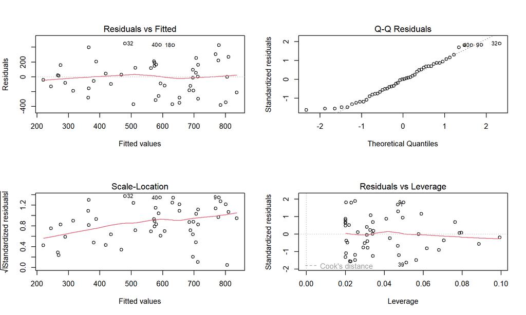

```r
par(mfrow = c(2, 2))
plot(m1)
```

```r
shapiro.test(m1$residuals)
```

```
##
##  Shapiro-Wilk normality test
##
## data:  m1$residuals
## W = 0.9639, p-value = 0.1295
```

**Q5:** Based on the residual plots and Shapiro–Wilk test: do the residuals of this model look approximately Normal and like they have constant variance? [5 points]

**Your answer:**

The residuals seem to be linearly increasing, so it appears that they are approximately normal. There is little to no grouping in the residuals vs fitted plot, and vertical spread seems equal about all of the points so this seems to have constant variance.

### Using a Binary Predictor

Let’s see what happens when we use a binary predictor in our model. We create a variable called “South” whenever the state is in the South, SouthWest, or SouthEast categories.

```r
lab8$South<- lab8$region %in% c("S", "SW", "SE")

m2<- lm(crime ~ South, data = lab8)
summary(m2)
```

```
##
## Call:
## lm(formula = crime ~ South, data = lab8)
##
## Residuals:
##     Min      1Q  Median      3Q     Max
## -444.14 -175.66  -26.14  171.11  636.59
##
## Coefficients:
##             Estimate Std. Error t value Pr(>|t|)
## (Intercept)   437.41      47.47   9.215 3.43e-12 ***
## SouthTRUE     307.73      73.24   4.202 0.000115 ***
## ---
## Signif. codes:  0 '***' 0.001 '**' 0.01 '*' 0.05 '.' 0.1 ' ' 1
##
## Residual standard error: 255.6 on 48 degrees of freedom
## Multiple R-squared:  0.2689, Adjusted R-squared:  0.2537
## F-statistic: 17.65 on 1 and 48 DF,  p-value: 0.0001145
```

**Q6:** How do you interpret the coefficient of `SouthTRUE`? [3 points]

- It represents the difference in average crime rate between Southern and Northern states.
- It represents the average crime rate in Southern states only.
- It has no interpretable meaning.

**Your answer:**

It represents the difference in average crime rate between Southern and Northern states.

Visualize this simple binary relationship:

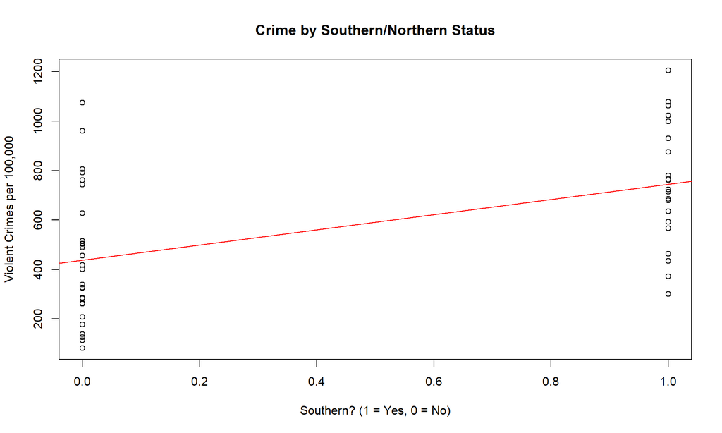

```r
plot(lab8$South, lab8$crime,
xlab = "Southern? (1 = Yes, 0 = No)",
ylab = "Violent Crimes per 100,000",
main = "Crime by Southern/Northern Status")
abline(m2, col = "red")
```

### Multiple linear regression

Now let’s add another predictor: percent of people who identify as White.

```r
m3 <- lm(crime ~ pctmetro + pctwhite, data = lab8)
summary(m3)
```

```
##
## Call:
## lm(formula = crime ~ pctmetro + pctwhite, data = lab8)
##
## Residuals:
##     Min      1Q  Median      3Q     Max
## -751.47 -121.88   20.72  107.56  454.53
##
## Coefficients:
##             Estimate Std. Error t value Pr(>|t|)
## (Intercept)  858.993    300.857   2.855  0.00638 **
## pctmetro       6.892      1.528   4.510 4.32e-05 ***
## pctwhite      -8.834      2.996  -2.949  0.00495 **
## ---
## Signif. codes:  0 '***' 0.001 '**' 0.01 '*' 0.05 '.' 0.1 ' ' 1
##
## Residual standard error: 223.3 on 47 degrees of freedom
## Multiple R-squared:  0.4538, Adjusted R-squared:  0.4306
## F-statistic: 19.53 on 2 and 47 DF,  p-value: 6.713e-07
```

**Q7:** Interpret the output from this model. **[11 points]**

1. What do these three coefficients tell us? (Use a phrase like “all else equal…” for the predictor coefficients and specify “when all the predictors are zero” for the intercept) [9 points]
2. How does the $R^2$ compare to the first simple linear regression model (m1)? [2 points]

**Your answer:**

1. What these coefficients tell us is that by holding one of the variables constant, or when all else is equal, with an increase in the target variable we expect to see a change in the crime percent by the amount specified by the coefficient. so when pctwhite is controlled for, increasing levels of metro living increase crime, and when metro living is controlled for, increasing levels of pctwhite decrease crime.

The model above indicates that the percent of people who identify as White is significantly associated with the crime rate (in the negative direction), controlling for the percent of people living in metropolitan areas. But we need to be careful: this relationship could still be confounded by other factors!

```r
m4<- lm(crime ~ pctwhite + poverty + pctmetro + single + South, data = lab8)
summary(m4)
```

```
##
## Call:
## lm(formula = crime ~ pctwhite + poverty + pctmetro + single +
##     South, data = lab8)
##
## Residuals:
##    Min     1Q Median     3Q    Max
## -390.8 -115.0  -19.2  117.8  394.3
##
## Coefficients:
##             Estimate Std. Error t value Pr(>|t|)
## (Intercept) -902.979    353.201  -2.557 0.014098 *
## pctwhite      -1.577      2.434  -0.648 0.520358
## poverty       15.200      6.595   2.305 0.025949 *
## pctmetro       7.217      1.169   6.171 1.89e-07 ***
## single        79.502     19.371   4.104 0.000173 ***
## SouthTRUE     61.908     57.629   1.074 0.288563
## ---
## Signif. codes:  0 '***' 0.001 '**' 0.01 '*' 0.05 '.' 0.1 ' ' 1
##
## Residual standard error: 161.1 on 44 degrees of freedom
## Multiple R-squared:  0.7339, Adjusted R-squared:  0.7037
## F-statistic: 24.27 on 5 and 44 DF,  p-value: 1.217e-11
```

**Q8:** What happens to the coefficient and p-value for `pctwhite` when you include these other predictors? [3 points]

**Your answer:**

The coefficient for pctwhite decreases when other predictors are added. This means that when other variables are accounted for, the crime rate seems to be less determined by pctwhite.

Moreover, the p value goes from 0.00495 to 0.52. Since the null hypothesis is that the coefficient is equal to zero, this means that with the addition of more variables we can say that pctwhite has no bearing on crime rates. Even though the coefficient is not equal to zero, there is a high enough error rate to make is so that the null is not rejected.

Finally, let’s compare the Adjusted $R^2$ when we remove pctwhite:

```r
m5<- lm(crime ~ poverty + pctmetro + single + South, data = lab8)
summary(m5)
```

```
##
## Call:
## lm(formula = crime ~ poverty + pctmetro + single + South, data = lab8)
##
## Residuals:
##     Min      1Q  Median      3Q     Max
## -369.24 -113.81  -21.63  112.22  389.95
##
## Coefficients:
##              Estimate Std. Error t value Pr(>|t|)
## (Intercept) -1091.370    199.268  -5.477 1.85e-06 ***
## poverty        15.374      6.547   2.348   0.0233 *
## pctmetro        7.369      1.138   6.474 6.16e-08 ***
## single         82.970     18.497   4.486 4.99e-05 ***
## SouthTRUE      68.983     56.219   1.227   0.2262
## ---
## Signif. codes:  0 '***' 0.001 '**' 0.01 '*' 0.05 '.' 0.1 ' ' 1
##
## Residual standard error: 160 on 45 degrees of freedom
## Multiple R-squared:  0.7314, Adjusted R-squared:  0.7075
## F-statistic: 30.63 on 4 and 45 DF,  p-value: 2.499e-12
```

**Q9:** *Notice that the Adjusted $R^2$ is slightly higher after removing pctwhite from the model.* What does this tell us about the role of pctwhite in predicting crime, if we have these other variables on hand? [3 points]

**Your answer:**

The adjusted r^2 is a measure of goodness of fit with the addition of variables. Since the removal of pctwhite increases this measure, (0.703 -> 0.707 ) it can be concluded that pctwhite reduces the accuracy of the model and therefore has no bearing on crime rates.

**Q10:** What happens to the Adjusted $R^2$ if we also remove the variable South from the model? Compare / contrast this finding with the p-value of this variable from the table above. [6 points]

**Your answer:**

-> before removing the variable, the adj r value was 0.707. After removing the variable, the value became 0.704 This implies that the addition of the south variable does not assist in predicting crime rates.

```r
# your code here

m5<- lm(crime ~ poverty + pctmetro + single, data = lab8)
summary(m5)
```

```
##
## Call:
## lm(formula = crime ~ poverty + pctmetro + single, data = lab8)
##
## Residuals:
##     Min      1Q  Median      3Q     Max
## -371.00 -121.31   -7.42  122.07  413.21
##
## Coefficients:
##              Estimate Std. Error t value Pr(>|t|)
## (Intercept) -1197.538    180.487  -6.635 3.22e-08 ***
## poverty        18.283      6.136   2.980   0.0046 **
## pctmetro        7.712      1.109   6.953 1.07e-08 ***
## single         89.401     17.836   5.012 8.43e-06 ***
## ---
## Signif. codes:  0 '***' 0.001 '**' 0.01 '*' 0.05 '.' 0.1 ' ' 1
##
## Residual standard error: 160.9 on 46 degrees of freedom
## Multiple R-squared:  0.7224, Adjusted R-squared:  0.7043
## F-statistic:  39.9 on 3 and 46 DF,  p-value: 7.452e-13
```

### Interactions

Let’s test whether the relationship between the percent of urban residents and crime *depends* on whether a state is in the South.

```r
m7<- lm(crime ~ poverty + pctmetro*South + single, data = lab8)
summary(m7)
```

```
##
## Call:
## lm(formula = crime ~ poverty + pctmetro * South + single, data = lab8)
##
## Residuals:
##     Min      1Q  Median      3Q     Max
## -246.14 -113.25  -17.07  122.89  299.21
##
## Coefficients:
##                     Estimate Std. Error t value Pr(>|t|)
## (Intercept)        -1107.485    192.569  -5.751 7.82e-07 ***
## poverty               19.993      6.705   2.982  0.00466 **
## pctmetro               6.217      1.232   5.045 8.30e-06 ***
## SouthTRUE           -323.016    197.428  -1.636  0.10895
## single                85.952     17.919   4.797 1.88e-05 ***
## pctmetro:SouthTRUE     5.291      2.562   2.065  0.04483 *
## ---
## Signif. codes:  0 '***' 0.001 '**' 0.01 '*' 0.05 '.' 0.1 ' ' 1
##
## Residual standard error: 154.5 on 44 degrees of freedom
## Multiple R-squared:  0.7551, Adjusted R-squared:  0.7273
## F-statistic: 27.13 on 5 and 44 DF,  p-value: 2.039e-12
```

**Q11:** Interpret these coefficients in context. [5 points]

**Your answer:** *Holding all else equal*, each percentage point increase in the population living in metropolitan areas, the model predicts 6.2 more violent crimes per 100,000 people (on average) for states in the North and 6.2 + 5.29 more violent crimes per 100,000 people (on average) for states in the South.

### Model diagnostics for the final model

Always check residuals!

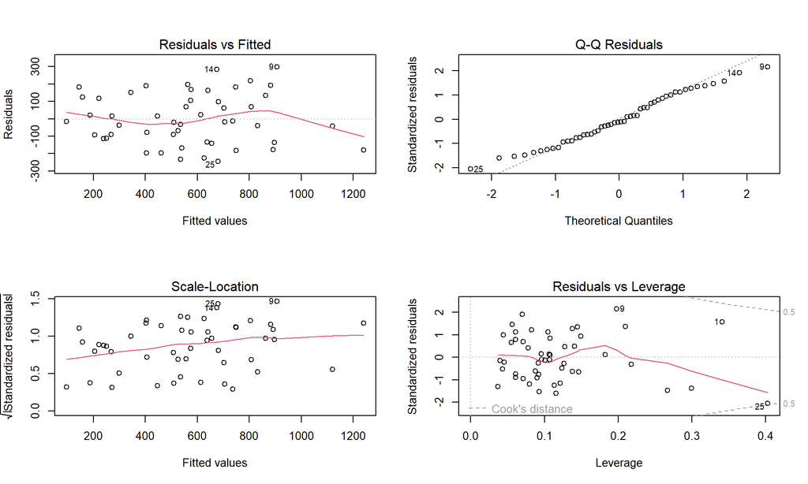

```r
par(mfrow = c(2, 2))
plot(m7)
```

```r
shapiro.test(m7$residuals)
```

```
##
##  Shapiro-Wilk normality test
##
## data:  m7$residuals
## W = 0.96558, p-value = 0.1522
```

**Q12:** Do the residuals appear to meet the assumptions of linear regression? [3 points]

**Your answer:**

it looks like there isnt any clustering, indicating uniform spread. For linear regression to hold it must feature homoscedacity which appears to be in the first leftmost plot. The QQ residuals also appear to be normally distributed, which is also an assumption for linear regression.

*Note: in the Residuals Vs Leverage plot, one of the points is almost (but not quite) outside the Cook’s distance guideline.*